# Problem Set 2

Ananth Josyula

Due Date: 2022/09/18 @ 11:59PM CST

## Getting Set Up

If you haven’t already, create a folder for this course, and then a subfolder within for the second lecture `Topic4_DataWrangling`, and two additional subfolders within `code` and `data`.

Open `RStudio` and create a new RMarkDown file (`.Rmd`) by going to `File -> New File -> R Markdown...`. Change the title to `"DS1000: Problem Set 2"` and the author to your full name. Save this file as `[LAST NAME]_ps2.Rmd` to your `code` folder.

If you haven’t already, download the `MI2020_ExitPoll.Rds` file from the course [github page](https://github.com/jbisbee1/DS1000-F2022/blob/master/Lectures/Topic4_DataWrangling/data/MI2020_ExitPoll.rds) and save it to your `data` folder.

**NB:** Please upload a `.pdf` version of your homework to Brightspace! To do so, you can either choose the `knit` dropdown of “Knit to PDF”, or you can open the standard `.html` output in your browser, then click print and choose “Print to PDF”.

## Question 1

Require `tidyverse` and load the `MI2020_ExitPoll.Rds` data to `MI_raw`.

```r
# INSERT CODE HERE
require(tidyverse)
MI_raw<-readRDS("../data/MI2020_ExitPoll.rds")
```

## Question 2 [1 point]

How many voters were from Wayne County?

```r
# INSERT CODE HERE
MI_raw %>%
  count(County == "WAYNE")
```

```
## # A tibble: 2 × 2
##   `County == "WAYNE"`     n
##   <lgl>               <int>
## 1 FALSE                1129
## 2 TRUE                  102
```

> - 102 voters were from Wayne County. 1129 voters were not from Wayne County.

## Question 3 [1 points]

Who did the majority of surveyed voters support in the 2020 presidential election?

```r
# INSERT CODE HERE
MI_raw %>%
  count(PRSMI20)
```

```
## # A tibble: 6 × 2
##   PRSMI20                                      n
##   <dbl+lbl>                                <int>
## 1 0 (NA) [Will/Did not vote for president]     6
## 2 1 [Joe Biden, the Democrat]                723
## 3 2 [Donald Trump, the Republican]           459
## 4 7 [Undecided/Don’t know]                     4
## 5 8 [Refused]                                 14
## 6 9 [Another candidate]                       25
```

> - The majority of surveyed voters supported [Joe Biden, the Democrat] in the 2020 presidential election. 723 out of 1231 voters supported [Joe Biden, the Democrat].

## Question 4 [2 points]

What proportion of women supported Trump? What proportion of men supported Biden?

```r
# INSERT CODE HERE
MI_raw %>%
  count(SEX)
```

```
## # A tibble: 2 × 2
##   SEX            n
##   <dbl+lbl>  <int>
## 1 1 [Male]     579
## 2 2 [Female]   652
```

```r
MI_raw %>%
  filter(SEX==2,PRSMI20==2) %>%
  count(PRSMI20)
```

```
## # A tibble: 1 × 2
##   PRSMI20                              n
##   <dbl+lbl>                        <int>
## 1 2 [Donald Trump, the Republican]   212
```

```r
MI_raw %>%
  filter(SEX==1,PRSMI20==1) %>%
  count(PRSMI20)
```

```
## # A tibble: 1 × 2
##   PRSMI20                         n
##   <dbl+lbl>                   <int>
## 1 1 [Joe Biden, the Democrat]   304
```

> - 212 out of 652 women voted for Trump. 304 out of 579 men voted for Biden. That is, about 1/(652/212) women voted for Trump and 1/(579/304) men voted for Biden.

## Question 5 [1 point]

Create a new object called `MI_clean` that contains only the following variables: - AGE10 - SEX - PARTYID - EDUC18 - PRMSI20 - QLT20 - LGBT - BRNAGAIN - LATINOS - QRACEAI - WEIGHT

```r
# INSERT CODE HERE
MI_clean <- MI_raw %>%
  select(SEX,AGE10,PARTYID,EDUC18,PRSMI20,QLT20,LGBT,BRNAGAIN,QRACEAI,WEIGHT)
```

## Question 6 [1 point]

Which of these variables have missing data recorded as `NA`?

```r
# INSERT CODE HERE
#glimpse(MI_clean)
MI_clean%>%
count(AGE10)
```

```
## # A tibble: 11 × 2
##    AGE10                         n
##    <dbl+lbl>                 <int>
##  1  1 [18 and 24,]              33
##  2  2 [25 and 29,]              28
##  3  3 [30 and 34,]              42
##  4  4 [35 and 39,]              46
##  5  5 [40 and 44,]              78
##  6  6 [45 and 49,]              83
##  7  7 [50 and 59,]             274
##  8  8 [60 and 64,]             143
##  9  9 [65 and 74,]             290
## 10 10 [75 or over?]            199
## 11 99 [[DON'T READ] Refused]    15
```

```r
MI_clean%>%
count(SEX)
```

```
## # A tibble: 2 × 2
##   SEX            n
##   <dbl+lbl>  <int>
## 1 1 [Male]     579
## 2 2 [Female]   652
```

```r
MI_clean%>%
count(PARTYID)
```

```
## # A tibble: 5 × 2
##   PARTYID                                 n
##   <dbl+lbl>                           <int>
## 1 1 [Democrat]                          425
## 2 2 [Republican]                        280
## 3 3 [Independent]                       416
## 4 4 [Something else]                     94
## 5 9 [[DON'T READ] Don’t know/refused]    16
```

```r
MI_clean%>%
count(EDUC18)
```

```
## # A tibble: 6 × 2
##   EDUC18                                                                       n
##   <dbl+lbl>                                                                <int>
## 1 1 [Never attended college]                                                 173
## 2 2 [Attended college but received no degree]                                262
## 3 3 [An Associate’s degree (AA or AS)]                                       190
## 4 4 [A Bachelor’s degree (BA or BS)]                                         293
## 5 5 [An advanced degree after a bachelor’s degree (such as JD, MA, MBA, M…   302
## 6 9 [[DON'T READ] Don’t know/refused]                                         11
```

```r
MI_clean%>%
count(PRSMI20)
```

```
## # A tibble: 6 × 2
##   PRSMI20                                      n
##   <dbl+lbl>                                <int>
## 1 0 (NA) [Will/Did not vote for president]     6
## 2 1 [Joe Biden, the Democrat]                723
## 3 2 [Donald Trump, the Republican]           459
## 4 7 [Undecided/Don’t know]                     4
## 5 8 [Refused]                                 14
## 6 9 [Another candidate]                       25
```

```r
MI_clean%>%
count(QLT20)
```

```
## # A tibble: 6 × 2
##   QLT20                                    n
##   <dbl+lbl>                            <int>
## 1  1 [Can unite the country]             125
## 2  2 [Is a strong leader]                138
## 3  3 [Cares about people like me]        121
## 4  4 [Has good judgment]                 205
## 5  9 [[DON'T READ] Don’t know/refused]    26
## 6 NA                                     616
```

```r
MI_clean%>%
count(LGBT)
```

```
## # A tibble: 4 × 2
##   LGBT                                     n
##   <dbl+lbl>                            <int>
## 1  1 [Yes]                                23
## 2  2 [No]                                570
## 3  9 [[DON'T READ] Don’t know/Refused]    23
## 4 NA                                     615
```

```r
MI_clean%>%
count(BRNAGAIN)
```

```
## # A tibble: 4 × 2
##   BRNAGAIN                                 n
##   <dbl+lbl>                            <int>
## 1  1 [Yes]                               211
## 2  2 [No]                                383
## 3  9 [[DON'T READ] Don’t know/refused]    22
## 4 NA                                     615
```

```r
MI_clean%>%
count(QRACEAI)
```

```
## # A tibble: 7 × 2
##   QRACEAI                                 n
##   <dbl+lbl>                           <int>
## 1 1 [White]                            1013
## 2 2 [Black]                             102
## 3 3 [Hispanic or Latino]                 20
## 4 4 [Asian]                              13
## 5 5 [American Indian]                    18
## 6 6 [[DON'T READ] Another race]          23
## 7 9 [[DON'T READ] Don’t know/refused]    42
```

```r
MI_clean%>%
count(WEIGHT)
```

```
## # A tibble: 411 × 2
##    WEIGHT     n
##     <dbl> <int>
##  1  0.100     1
##  2  0.113     1
##  3  0.119     1
##  4  0.133     2
##  5  0.141     1
##  6  0.142     1
##  7  0.144     1
##  8  0.146     1
##  9  0.147     1
## 10  0.149     5
## # … with 401 more rows
```

> - Variables QLT20, LGBT, and BRNAGAIN all have missing data recorded as “NA”.

## Question 7 [1 point]

Are there **unit non-response** data in the `AGE10` variable? If so, how are they recorded?

```r
# INSERT CODE HERE
MI_clean %>%
  count(AGE10)
```

```
## # A tibble: 11 × 2
##    AGE10                         n
##    <dbl+lbl>                 <int>
##  1  1 [18 and 24,]              33
##  2  2 [25 and 29,]              28
##  3  3 [30 and 34,]              42
##  4  4 [35 and 39,]              46
##  5  5 [40 and 44,]              78
##  6  6 [45 and 49,]              83
##  7  7 [50 and 59,]             274
##  8  8 [60 and 64,]             143
##  9  9 [65 and 74,]             290
## 10 10 [75 or over?]            199
## 11 99 [[DON'T READ] Refused]    15
```

> - There are unit non-response data in the “AGE10” variable called 99 [[DON’T READ] Refused]. They are recorded with a 99 dbl and [[DON’T READ] Refused] lbl.

## Question 8 [1 point]

What about in the PARTYID variable? How is unit non-response data recorded there?

```r
# INSERT CODE HERE
MI_clean %>%
  count(PARTYID)
```

```
## # A tibble: 5 × 2
##   PARTYID                                 n
##   <dbl+lbl>                           <int>
## 1 1 [Democrat]                          425
## 2 2 [Republican]                        280
## 3 3 [Independent]                       416
## 4 4 [Something else]                     94
## 5 9 [[DON'T READ] Don’t know/refused]    16
```

> - There are unit non-response data in the “PARTYID” variable called 9 [[DON’T READ] Don’t know/refused]. They are recorded with a 9 dbl and [[DON’T READ] Don’t know/refused] lbl.

## Question 9 [1 point]

Let’s create a new variable called `preschoice` that converts `PRSMI20` to a character. To do this, install the `sjlabelled` package and then create a new dataset called `lookup` that contains both the numeric value of the `PRSMI20` variable as well as the character label. Then merge this `lookup` dataframe to the `MI_clean` `tibble` with `left_join`.

```r
# INSERT CODE HERE
#install.packages("sjlabelled")
labels<-sjlabelled::get_labels(MI_clean$PRSMI20)
values<-sjlabelled::get_values(MI_clean$PRSMI20)
lookup<-data.frame(PRSMI20 = values, preschoice = labels)
MI_clean<-MI_clean %>%
  left_join(lookup, by = c("PRSMI20"),)
```

## Question 10 [1 point]

Do the same for the `QLT20` variable, the `AGE10` variable, and the `LGBT` variable. For each variable, make the character version `Qlty` for `QLT20`, `Age` for `AGE10`, and `Lgbt_clean` for `LGBT`. EXTRA CREDIT: create a function to repeat this task easily.

```r
# INSERT CODE HERE
relabFn<-function(data,column) {
  labels<-sjlabelled::get_labels(data[[column]])
  values<-sjlabelled::get_values(data[[column]])
  return(data.frame(orig = values, lab = labels))
}


lookupQLT20<-relabFn(data = MI_clean, column = "QLT20") %>%
  rename(QLT20 = orig, Qlty = lab)
lookupAGE10<-relabFn(data = MI_clean, column = "AGE10") %>%
  rename(AGE10 = orig, Age = lab)
lookupLGBT<-relabFn(data = MI_clean, column = "LGBT") %>%
  rename(LGBT = orig, Lgbt_clean = lab)


MI_clean<-MI_clean %>%
  left_join(lookupQLT20, by = c("QLT20"),) %>%
  left_join(lookupAGE10, by = c("AGE10"),) %>%
  left_join(lookupLGBT, by = c("LGBT"),)
```

## Question 11 [1 point]

For each of these new variables, replace the unit non-response data label with `NA`.

```r
# INSERT CODE HERE
MI_clean<-MI_clean %>%
  mutate(Age = ifelse(AGE10 == 99, NA, AGE10)) %>%
  mutate(Qlt = ifelse(is.na(QLT20), NA, QLT20)) %>%
  mutate(Lgbt_clean = ifelse(is.na(LGBT), NA, LGBT))   %>%
  mutate(preschoice = ifelse(is.na(PRSMI20), NA, PRSMI20))
```

## Question 12 [2 points]

What proportion of LGBT-identifying voters supported Trump?

```r
# INSERT CODE HERE
MI_clean %>%
  count(LGBT)
```

```
## # A tibble: 4 × 2
##   LGBT                                     n
##   <dbl+lbl>                            <int>
## 1  1 [Yes]                                23
## 2  2 [No]                                570
## 3  9 [[DON'T READ] Don’t know/Refused]    23
## 4 NA                                     615
```

```r
MI_clean%>%
  filter(Lgbt_clean == "Yes",preschoice == "Donald Trump, the Republican" ) %>%
  count(Lgbt_clean)
```

```
## # A tibble: 0 × 2
## # … with 2 variables: Lgbt_clean <dbl>, n <int>
```

## Question 13 [2 points]

Convert `AGE10` to a numeric variable and replace the unit non-response data code with `NA`. What is the average age category in the data? What age bracket does this define?

```r
# INSERT CODE HERE
lookup <- relabFn(data=MI_clean, column = 'AGE10')
lookup %>%
  rename(AGE10 = orig, age_clean = lab)
```

```
##    AGE10            age_clean
## 1      1           18 and 24,
## 2      2           25 and 29,
## 3      3           30 and 34,
## 4      4           35 and 39,
## 5      5           40 and 44,
## 6      6           45 and 49,
## 7      7           50 and 59,
## 8      8           60 and 64,
## 9      9           65 and 74,
## 10    10          75 or over?
## 11    99 [DON'T READ] Refused
```

```r
MI_clean <- MI_clean %>%
  mutate (AGE10 = ifelse(AGE10 == 99, NA, AGE10))

MI_clean %>%
  summarise(avgAge = mean(AGE10, na.rm=T))
```

```
## # A tibble: 1 × 1
##   avgAge
##    <dbl>
## 1   7.36
```

## Question 14 [2 points]

Plot the distribution of ages in the data. EXTRA CREDIT: color by the number of voters in each bracket that supported Trump, Biden, or someone else. Make sure to drop voters who didn’t indicate who they voted for **AND** those who didn’t indicate their age.

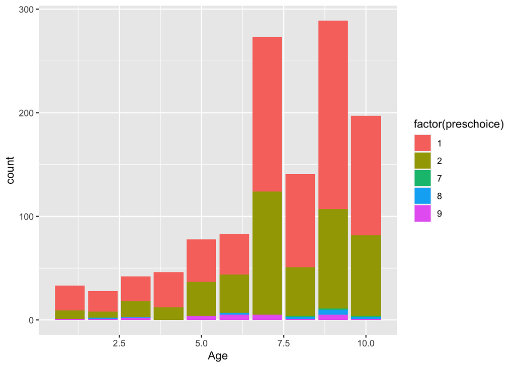

```r
# INSERT CODE HERE
MI_clean <- MI_clean%>%
  drop_na(preschoice) %>%
  drop_na(Age)
MI_clean %>%
  ggplot (aes(x = Age, fill = factor(preschoice)))+
  geom_bar (stat = 'count')
```

## Question 15 [3 points]

In a two-way race (i.e., dropping those who voted for a candidate other than Biden or Trump), which age group most heavily favored Trump? Which most heavily favored Biden? Discuss some theories for why this might be the case. EXTRA CREDIT: plot this answer.

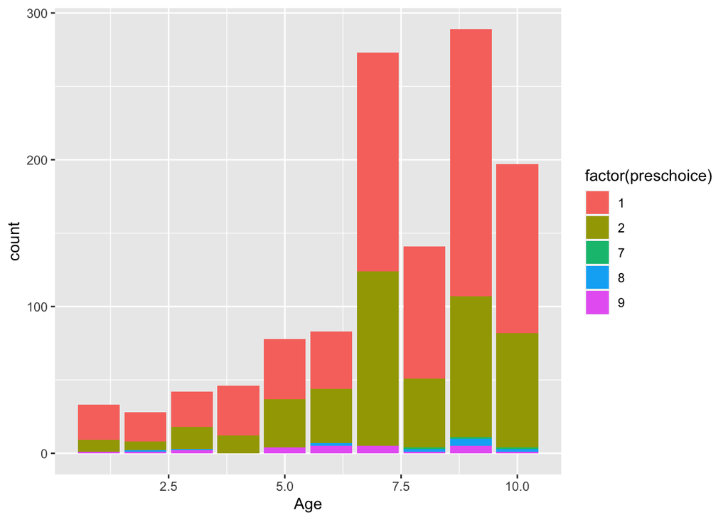

```r
# INSERT CODE HERE
MI_clean <- MI_clean %>%
  mutate(preschoice = ifelse(grepl('Another|Undecided|Will', preschoice), NA, preschoice)) %>%
  drop_na(preschoice)

MI_clean %>%
  ggplot (aes(x= Age, fill= factor(preschoice)))+
  geom_bar (stat = 'count')
```